# Data Analysis Final Project

## Mobile Application Stores Analysis

Kaggle is used to get two datasets; One for Google Play Store applications data, and the second for Apple Store applications data.

*The Android Play Store data after cleaning*

|  | App | Category | Rating | Reviews | Size | Price | Content Rating | Current Ver |
| --- | --- | --- | --- | --- | --- | --- | --- | --- |
| 2218 | High Blood Pressure Symptoms | MEDICAL | 4.0 | 531 | 2300000.0 | 0.0 | Everyone | 1.0 |
| 9641 | EZ Video Download for Facebook | SOCIAL | 4.1 | 34079 | 1300000.0 | 0.0 | Teen | 2.001 |
| 2955 | Backgrounds (HD Wallpapers) | PERSONALIZATION | 4.7 | 202474 | 3000000.0 | 0.0 | Teen | 2.6.0 |
| 3254 | Music - Mp3 Player | VIDEO_PLAYERS | 4.4 | 259605 | 3100000.0 | 0.0 | Everyone | 1.6.1 |
| 6909 | CI Crew | FAMILY | 0.0 | 1 | 30000000.0 | 0.0 | Everyone | 0.7 |
| 6278 | BS MAPS | MAPS_AND_NAVIGATION | 4.5 | 6 | 2500000.0 | 0.0 | Everyone | 2.1 |
| 929 | Capital One® Mobile | FINANCE | 4.6 | 510392 | 79000000.0 | 0.0 | Everyone | 5.38.1 |

```
<class 'pandas.core.frame.DataFrame'>
RangeIndex: 10358 entries, 0 to 10357
Data columns (total 8 columns):
 #   Column          Non-Null Count  Dtype
---  ------          --------------  -----
 0   App             10358 non-null  object
 1   Category        10358 non-null  object
 2   Rating          10358 non-null  float64
 3   Reviews         10358 non-null  int64
 4   Size            10358 non-null  float64
 5   Price           10358 non-null  float64
 6   Content Rating  10358 non-null  object
 7   Current Ver     10358 non-null  object
dtypes: float64(3), int64(1), object(4)
memory usage: 647.5+ KB
```

The Apple Store data after cleaning

|  | track_name | size_bytes | price | rating_count_tot | user_rating | ver | cont_rating | prime_genre |
| --- | --- | --- | --- | --- | --- | --- | --- | --- |
| 3819 | Matchsticks ~ Free Puzzle Game with Matches | 32492544 | 0.00 | 212 | 4.5 | 1.9 | Everyone | GAME |
| 3709 | Polarr Photo Editor - Photo Editing Tools for All | 57919488 | 0.00 | 2246 | 4.5 | 3.7.1 | Everyone | PHOTOGRAPHY |
| 3642 | Worms™ 4 | 268636160 | 4.99 | 380 | 3.5 | 1.07 | Teen 9+ | GAME |
| 2876 | 小猿搜题-中小学拍照搜题作业帮手 | 77407232 | 0.00 | 31 | 4.5 | 5.4.0 | Everyone | Education |
| 3338 | Musical Video Creator Music+Videos illuminati Pro | 17254400 | 0.00 | 1588 | 3.5 | 3.0 | Mature 17+ | ENTERTAINMENT |
| 6886 | Hexy! | 146126848 | 0.00 | 51 | 2.5 | 1.2.4 | Everyone | GAME |
| 3245 | Amazon Prime Now | 48007168 | 0.00 | 895 | 3.0 | 4.0 | Everyone | SHOPPING |

- Final DataFrame to work on & analyze

|  | Store | App | Category | Rating | Reviews | size_bytes | price_USD | cont_rating | ver |
| --- | --- | --- | --- | --- | --- | --- | --- | --- | --- |
| 1311 | Apple Store | The Amazing Spider-Man | GAME | 4.5 | 17895 | 829148559 | 6.99 | Teen 9+ | 1.0.3 |
| 6 | Google Play Store | Smoke Effect Photo Maker - Smoke Editor | ART_AND_DESIGN | 3.8 | 178 | 1.9e+07 | 0 | Everyone | 1.1 |
| 8508 | Google Play Store | Learn German: Die Bienenretter | FAMILY | 4 | 25 | 7.9e+07 | 0 | Everyone | 1.0.5 |
| 959 | Apple Store | Railway Route Search | MAPS_AND_NAVIGATION | 3 | 5 | 46950400 | 0 | Everyone | 3.17.1 |
| 536 | Google Play Store | Transenger – Ts Dating and Chat for Free | DATING | 3.6 | 8 | 1.4e+07 | 0 | Mature 17+ | 1.4.0 |
| 1865 | Apple Store | Prime Photos from Amazon | PHOTOGRAPHY | 4 | 10511 | 76257280 | 0 | Everyone | 4.5.1 |
| 9449 | Google Play Store | EU-Schwerbehinderung | NEWS_AND_MAGAZINES | 0 | 3 | 3.2e+07 | 0 | Teen 9+ | 2.0.3.53 |
| 1350 | Apple Store | Disney Channel – Watch Full Episodes, Movies & TV | ENTERTAINMENT | 3.5 | 21082 | 132038656 | 0 | Everyone | 5.7.0 |
| 4327 | Google Play Store | Flight Simulator X 2016 Free | FAMILY | 3.8 | 44636 | 1.1e+07 | 0 | Everyone | Varies with device |

```
<class 'pandas.core.frame.DataFrame'>
Int64Index: 17555 entries, 0 to 7196
Data columns (total 9 columns):
 #   Column       Non-Null Count  Dtype
---  ------       --------------  -----
 0   Store        17555 non-null  object
 1   App          17555 non-null  object
 2   Category     17555 non-null  object
 3   Rating       17555 non-null  object
 4   Reviews      17555 non-null  object
 5   size_bytes   17555 non-null  object
 6   price_USD    17555 non-null  object
 7   cont_rating  17555 non-null  object
 8   ver          17555 non-null  object
dtypes: object(9)
memory usage: 1.3+ MB
```

### Visulizations

- **What is the most familiar application Category on stores?**

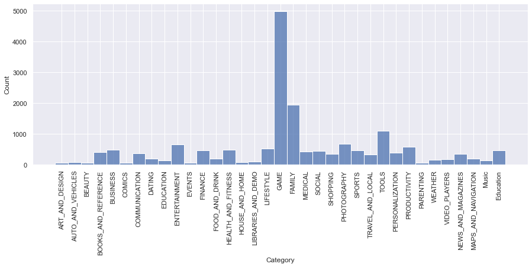

**What are the ratings of the most expensive applications (above 100$)?**

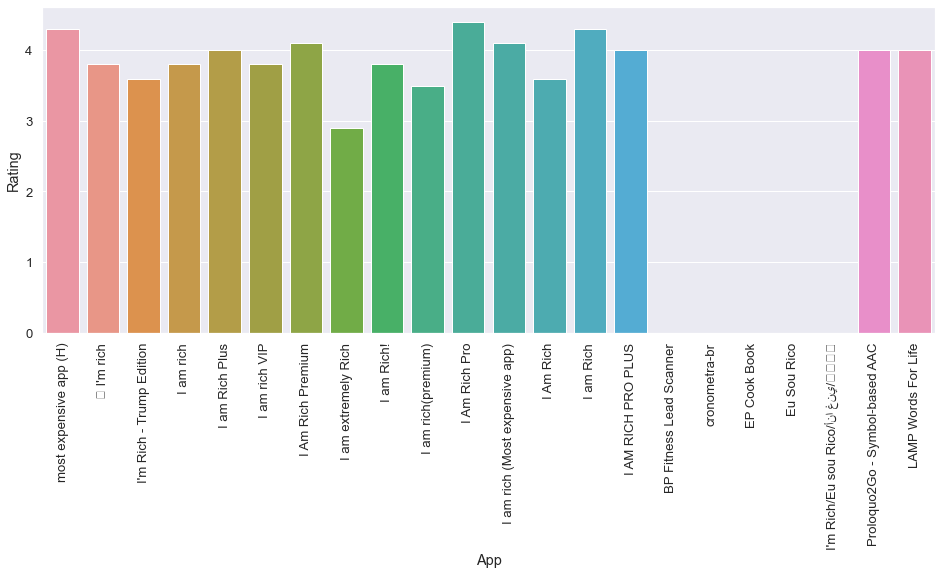

**Difference of ratings of categories per store.**

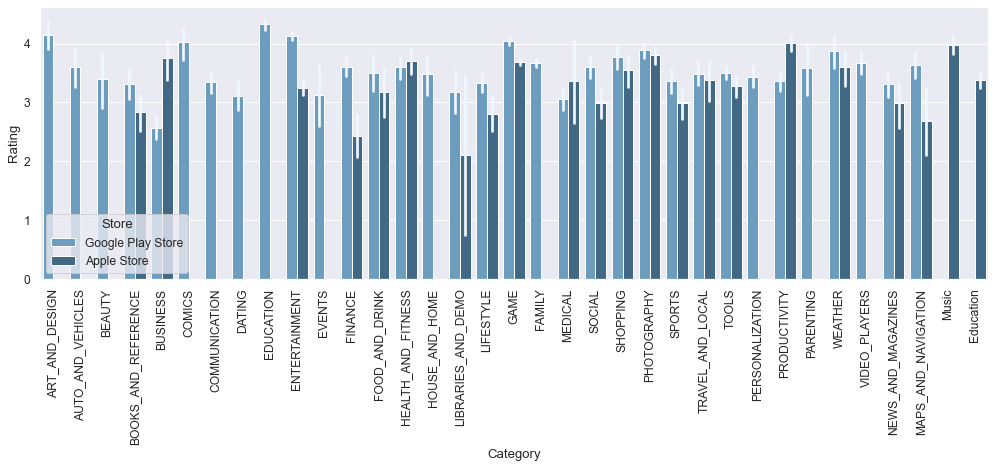

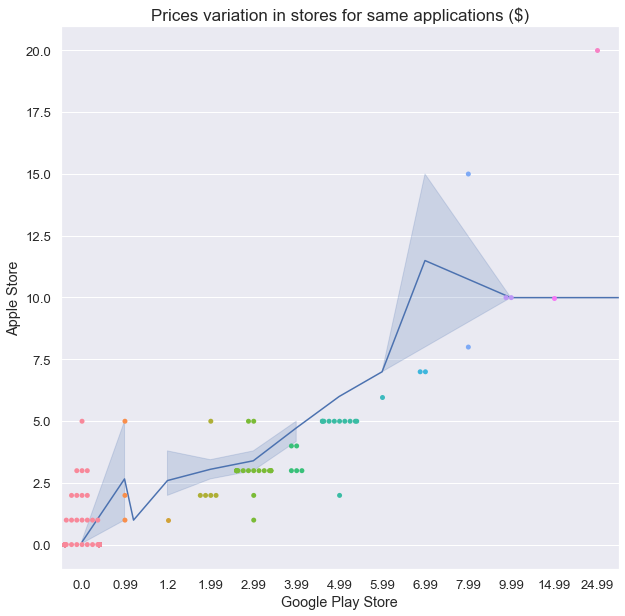

Although applications' prices tend to be close in both stores, however, some may encounter a difference.

Prices variation per content type

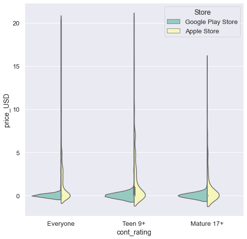

### Arranging the dataset for learning

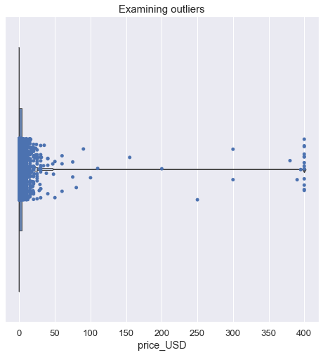

Most of applications are Free, however some are with values far greater than zero, so we will not delete all outliers. This shall be handeled as an imbalanced data.

After that, data is ready for Machine Learning models to predict for ratings

#### Recommendations

It's better to increase the data used in the analysis, whether searching for additional datasets, scraping different stores data, or getting an API for the Android/Apple/Huawei/… stores.